# Pravděpodobnost a Statistika

Author

Marie Kleckerová

# Příprava na Zápočtový test

### ZS 2024/2025

```r
library(tidyverse)
library(ggplot2)
library(knitr)
library(dplyr)
library(readxl)
library(readr)
library(DescTools) # statistika
library(psych) # statistika
library(GGally) # funkce ggpairs()
rm(list=ls())
df <- read_excel("Data_vyzkum.xlsx")
```

# 1. Kategorická (kvalitativní) proměnná

- **nominální** (neseřazená) = barva očí, typ ovoce, kraj…
- **ordinální** (seřazená) - nelze změřit vzdálenost mezi kategoriemi = nálada, vzdělání …

## 1. 1. Popisná statistika kategorické proměnné

- určujeme:

### ABSOLUTNÍ ČETNOST

- počet výskytů jednotlivých kategorií v datasetu

#### a) nominální proměnná

```r
absolutni_cetnost <- table(df$sloupec)
```

```r
absolutni_cetnost <- table(df$Bydliště)
absolutni_cetnost
```

```
  Čechy  Morava Slezsko
     32      22       6
```

#### b) ordinální proměnná

- seřazení dat dle kategorií

```r
df$sloupec <- ordered(df$sloupec, levels = c("", "", "", ...))
```

```r
df$Vzdělání <- ordered(df$Vzdělání, levels = c("ZŠ", "SŠ", "VŠ"))
```

```r
absolutni_cetnost <- table(df$sloupec)
```

```r
absolutni_cetnost <- table(df$Vzdělání)
absolutni_cetnost
```

```
ZŠ SŠ VŠ
 4 34 22
```

- **kumulativní absolutní četnost**

```r
kumulativni_absolutni_cetnost <- cumsum(absolutni_cetnost)
kumulativni_absolutni_cetnost
```

```
ZŠ SŠ VŠ
 4 38 60
```

### RELATIVNÍ ČETNOST

- podíl jednotlivých kategorií vůči celkovému počtu dat v datasetu
- absolutní četnost kategorie / počet hodnot ve sloupci
- vyjádřeno jako procento/zlomek

#### a) nominální proměnná

```r
relativni_cetnost <- round(prop.table(table(df$sloupec)), 2) * 100 # V procentech.
relativni_cetnost
```

```r
relativni_cetnost <- round(prop.table(table(df$Bydliště)),2) * 100
relativni_cetnost
```

```
  Čechy  Morava Slezsko
     53      37      10
```

#### b) ordinální proměnná

```r
relativni_cetnost <- round(prop.table(table(df$sloupec)),3) * 100
relativni_cetnost
```

```r
relativni_cetnost <- round(prop.table(table(df$Vzdělání)),3) * 100
relativni_cetnost
```

```
  ZŠ   SŠ   VŠ
 6.7 56.7 36.7
```

- **kumulativní relativní četnost**

```r
kumulativni_relativni_cetnost <- cumsum(relativni_cetnost)
kumulativni_relativni_cetnost
```

```
   ZŠ    SŠ    VŠ
  6.7  63.4 100.1
```

### Tabulka četností

```r
tabulka_cetnosti <- cbind("Absolutní četnost"=absolutni_cetnost, "Relativní četnost (%)" = relativni_cetnost)
tabulka_cetnosti
```

```
   Absolutní četnost Relativní četnost (%)
ZŠ                 4                   6.7
SŠ                34                  56.7
VŠ                22                  36.7
```

```r
tabulka_cetnosti <- cbind("Absolutní četnost"=absolutni_cetnost,
                          "Kumulativní absolutní četnost"=kumulativni_absolutni_cetnost,
                          "Relativní četnost (%)" = relativni_cetnost,
                          "Kumulativní relativní četnost (%)" = kumulativni_relativni_cetnost)
tabulka_cetnosti
```

```
   Absolutní četnost Kumulativní absolutní četnost Relativní četnost (%)
ZŠ                 4                             4                   6.7
SŠ                34                            38                  56.7
VŠ                22                            60                  36.7
   Kumulativní relativní četnost (%)
ZŠ                               6.7
SŠ                              63.4
VŠ                             100.1
```

## 1. 2. Grafické znázornění kategorické proměnné

### Sloupcový graf

```r
df <- data.frame(random_sloupec, kategorie)
cetnost <- df %>% group_by(kategorie) %>% summarise(n=n())    # sloupec n s četnostmi kategorií
cetnost <- cetnost %>% arrange(desc(n))                       # seřazení sestupně
cetnost <- head(cetnost, 10)                                  # ponechá 10 kategoríí s největší četností
celkem <- nrow(df)                                            # počet hodnot ve sloupci
cetnost <- cetnosti %>% mutate(relativni_cetnost=(n/celkem)*100)  # nový sloupec relativní četnost (%)

cetnost %>% ggplot(aes(kategorie,relativni_cetnost, fill=kategorie)) +   # sloupcový graf
  geom_col() +
  coord_flip()  +                                                        # převrácení na výšku
  labs(title = "", x = "", y = "")  +
  facet_wrap(~rozdeleni_dle_jine_kategorie) +
  theme(plot.title = element_text(face = "bold"))
```

```r
df %>%
  ggplot(aes(x = kategorie)) +
  geom_bar(fill="deeppink") +
  labs(title = "", x = "", y = "") +
  theme(plot.title = element_text(face = "bold"))
```

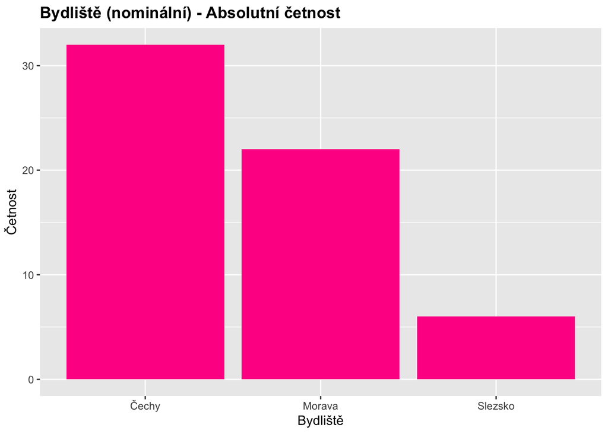

```r
df %>%
  ggplot(aes(x = Bydliště)) +
  geom_bar(fill="deeppink") +
  labs(title = "Bydliště (nominální) - Absolutní četnost", x = "Bydliště", y = "Četnost") +
  theme(plot.title = element_text(face = "bold"))
```

### Koláčový graf

```r
df %>%
  ggplot(aes(x = "", y = hodnoty, fill = kategorie)) +
  geom_col() +
  coord_polar("y") +
  scale_fill_discrete(name = "kategorie") +
  labs(title = "", y = "") +
  theme(plot.title = element_text(face = "bold"))
```

```r
df %>%
  ggplot(aes(x = "", fill = Kategorie)) +
  geom_bar(width = 1, color = "white") +
  coord_polar("y")+
  scale_fill_discrete(name = "Kategorie") +
  labs(title="", y="") +
  theme_void() +
  theme(plot.title = element_text(face = "bold"))
```

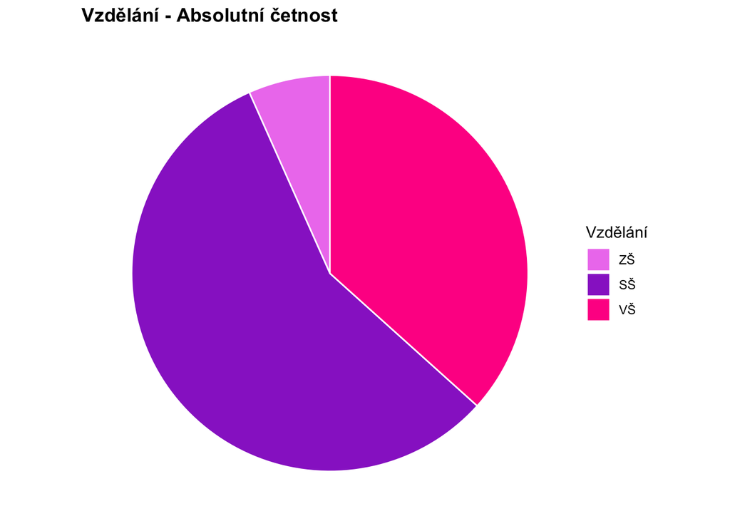

```r
df %>%
  ggplot(aes(x = "", fill = Vzdělání)) +
  geom_bar(width = 1, color = "white") +
  coord_polar("y")+
  labs(title="Vzdělání - Absolutní četnost")+
  theme_void() +
  scale_fill_manual(
    values = c("VŠ" = "deeppink",
               "SŠ" = "darkorchid",
               "ZŠ" = "violet")) +
  labs(title = "Vzdělání - Absolutní četnost") +
  theme_void() +
  theme(plot.title = element_text(face = "bold"))
```

# 2. Číselná (kvantitativní) proměnná

- **dělení**:
  1. **nespojitá (diskrétní)**
  - konkrétní, oddělené hodnoty (celá čísla)
  - počet dětí, počet žáků
  2. **spojitá**
  - hodnoty mohou nabývat libovolného čísla v určitém intervalu
  - výška, hmotnost, teplota, čas

## 2. 1. Popisná statistika číselné proměnné

### Diskrétní proměnná

- tabulka absolutních a relativních četností, viz. kategoriální proměnná

### Spojitá proměnná

- popisná statistika **polohy** (průměr, medián, modus, minimum, maximum), **variability** (rozptyl, směrodatná odchylka, rozmezí, kvartily, šikmost, kurtóza)

### Frekvenční rozdělení

- četnost v jednotlivých intervalech

```r
hranice <- c(-Inf, , , , Inf) # stanovení hraničních bodů intervalů
sloupec_intervaly <- cut(df$sloupec, breaks = hranice, labels = c("Pod ...", "", "", "Nad ..."))
sloupec_absolutni_cetnost <- table(sloupec_intervaly)
sloupec_absolutni_cetnost

sloupec_relativni_cetnost <- prop.table(table(sloupec_intervaly))
sloupec_relativni_cetnost
```

```r
hranice <- c(-Inf, 18.5, 25, 30, Inf)
bmi_intervaly <- cut(df$BMI, breaks = hranice, labels = c("Pod 18.5", "18.5-25", "25-30", "Nad 30"))

# ABSOLUTNÍ ČETNOST
bmi_absolutni_cetnost <- table(bmi_intervaly)

# RELATIVNÍ ČETNOST
bmi_relativni_cetnost <- round(prop.table(table(bmi_intervaly)),2) * 100

# TABULKA ČETNOSTÍ
tabulka_cetnosti <- cbind("Absolutní četnost"=bmi_absolutni_cetnost, "Relativní četnost (%)" = bmi_relativni_cetnost)
tabulka_cetnosti
```

```
         Absolutní četnost Relativní četnost (%)
Pod 18.5                 8                    13
18.5-25                 24                    40
25-30                   13                    22
Nad 30                  15                    25
```

### STATISTIKY POLOHY

```r
# PRŮMĚR -  součet hodnot / počet hodnot ; citlivý na odlehlé hodnoty
prumer <- mean(df$sloupec)

# MEDIÁN = 2. KVARTIL; prostřední hodnota seřazených dat ; robustní vůči odlehlým hodnotám
median <- median(df$sloupec)

# MODUS = hodnota s nejvíce výskyty, nemá modus, unimodální, bimodální, multimodální
modus <- function(x) {
  unikatni_hodnoty <- unique(x)
  unikatni_hodnoty[which.max(tabulate(match(x, unikatni_hodnoty)))]
  }
modus(df$sloupec)

# MINIMUM a MAXIMUM
minimum <- min(df$sloupec)
maximum <- max(df$sloupec)

# 1. KVARTIL = DOLNÍ KVARTIL ; 25% dat je menší než tento počet
dolni_kvartil <- quantile(df$sloupec, 0.25)

# 3. KVARTIL = HORNÍ KVARTIL; 75% dat je menší než tento počet
horni_kvartil <- quantile(df$sloupec, 0.75)
```

```r
summary(df$Hmotnost)
```

```
   Min. 1st Qu.  Median    Mean 3rd Qu.    Max.
  40.40   65.97   75.95   75.79   84.78  135.00
```

```r
describe(df$Hmotnost)
```

```
   vars  n  mean   sd median trimmed   mad  min max range skew kurtosis  se
X1    1 60 75.79 16.3  75.95    75.6 13.94 40.4 135  94.6 0.45      1.4 2.1
```

### STATISTIKY VARIABILITY

```r
# ROZPTYL = průměrná kvadratická odchylka od průměru, jak moc jsou hodnoty rozptýlené kolem průměru
rozptyl <- var(df$sloupec)

# SMĚRODATNÁ ODCHYLKA = odmocnina z rozptylu; jak moc se průměrně liší hodnoty od průměru
smerodatna_odchylka <- sd(df$sloupec)

# VARIAČNÍ KOEFICIENT = relativní rozptyl dat vůči průměru, v %, možnost srovnávat různé datasety, jednotky
variacni_koeficient <- sd(df$sloupec) / mean(df$sloupec) * 100
```

## 2. 2. Grafické znázornění číselné proměnné

### Frekvenční polygon

- diskrétní proměnné

```r
# potřebná tabulka četností
sloupec_cetnost <- as.data.frame(table(df$sloupec))

# přejmenování sloupců
names(sloupec_cetnost) <- c("sloupec", "Četnost")

# graf
sloupec_cetnost %>%
  ggplot(aes(x = sloupec, y = Četnost)) +
  geom_line(aes(group = 1), color="deeppink") +
  geom_segment(aes(x = sloupec,
                   xend = sloupec,
                   y = 0,
                   yend = Četnost),
               linetype = "dashed",
               color="deeppink") +
  labs(title = "Frekvenční polygon pro sloupec", x = " ", y = "Četnost") +
  theme(plot.title = element_text(face = "bold"))
```

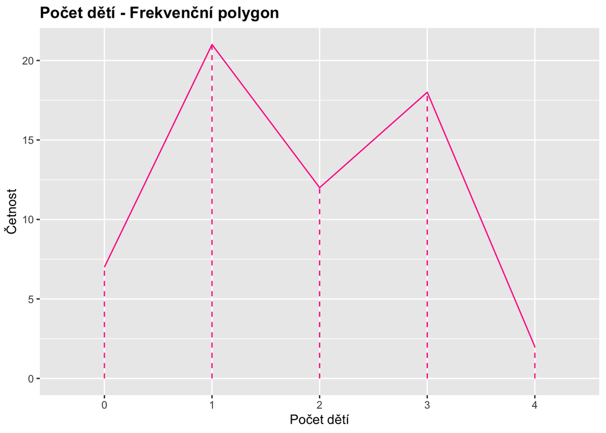

```r
deti_cetnost <- as.data.frame(table(df$Dětí))
names(deti_cetnost) <- c("Počet dětí", "Četnost")
deti_cetnost %>%
  ggplot(aes(x = `Počet dětí`, y = Četnost)) +
  geom_line(aes(group = 1), color="deeppink") +
  geom_segment(aes(x = `Počet dětí`,
                   xend = `Počet dětí`,
                   y = 0,
                   yend = Četnost),
               linetype = "dashed",
               color = "deeppink") +
  labs(title = "Počet dětí - Frekvenční polygon", x = "Počet dětí", y = "Četnost") +
  theme(plot.title = element_text(face = "bold"))
```

### Histogram

- spojité proměnné

```r
df %>%
  ggplot(aes(x = sloupec)) +
  geom_histogram(breaks = seq(od, do, delka_intervalu),                 # dílky histogramu
                 color="black",
                 fill = "deeppink") +
  scale_x_continuous(breaks = seq(od, do, delka_intervalu)) +           # osa histogramu
  labs(title = "", x = "", y = "Četnost") +
  theme(plot.title = element_text(face = "bold"))
```

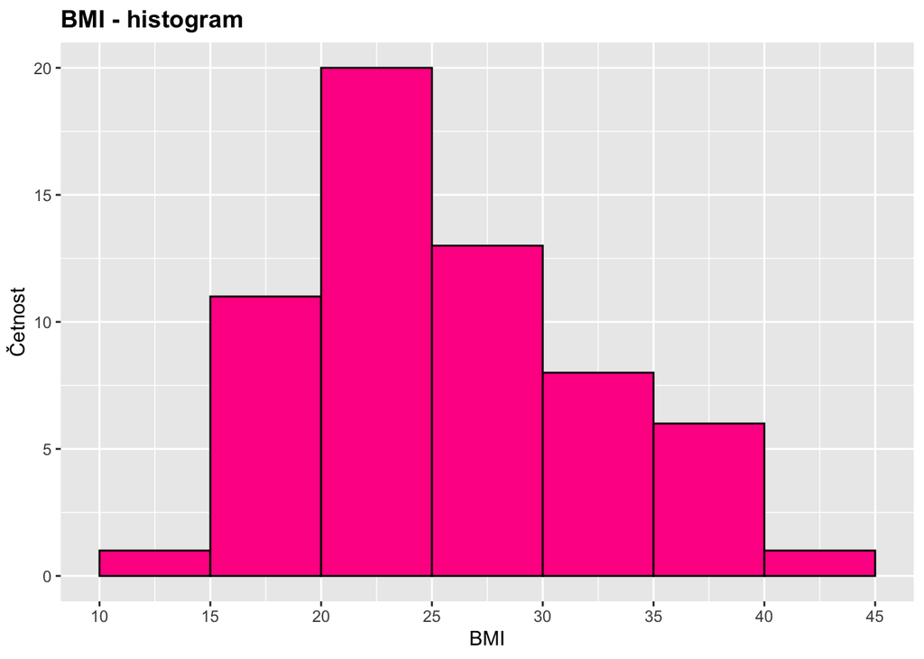

```r
df %>%
  ggplot(aes(x = BMI)) +
  geom_histogram(breaks = seq(10, 45, 5),
                 color="black",
                 fill = "deeppink") +
  scale_x_continuous(breaks = seq(10, 45, 5)) +
  labs(title = "BMI - histogram", x = "BMI", y = "Četnost") +
  theme(plot.title = element_text(face = "bold"))
```

```r
  #stat_bin(binwidth = 5, geom = "text", aes(label = after_stat(count)), vjust = -0.5)
```

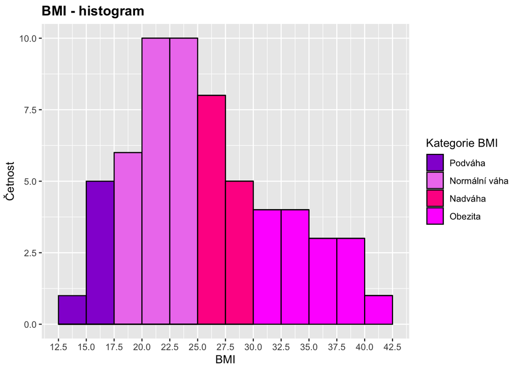

```r
df %>%
  ggplot(aes(
    x = BMI,
    fill = cut(BMI,
               breaks = c(-Inf, 17.5, 25, 30, Inf),
               labels = c("Podváha", "Normální váha", "Nadváha", "Obezita")))) +
  geom_histogram(breaks = seq(12.5, 42.5, 2.5),
                 color = "black") +
  scale_x_continuous(breaks = seq(12.5, 42.5, 2.5)) +
  scale_fill_manual(values = c("Podváha" = "darkviolet",
                               "Normální váha" = "violet",
                               "Nadváha" = "deeppink",
                               "Obezita" = "magenta")) +
  labs(title = "BMI - histogram", x = "BMI", y = "Četnost", fill = "Kategorie BMI") +
  theme(plot.title = element_text(face = "bold"))
```

### Boxplot (Krabicový graf)

```r
df %>%
  ggplot(aes(x="", y=sloupec)) +
  stat_boxplot(geom = "errorbar", width = 0.15, fill = "deeppink") +                  # udělá "tykadla"
  geom_boxplot(outlier.shape = 20, outlier.size = 3) +
  theme(legend.position="right") +
  labs(title= "", x="-", y="sloupec") +
  theme(plot.title = element_text(face = "bold")) +
  coord_flip()
```

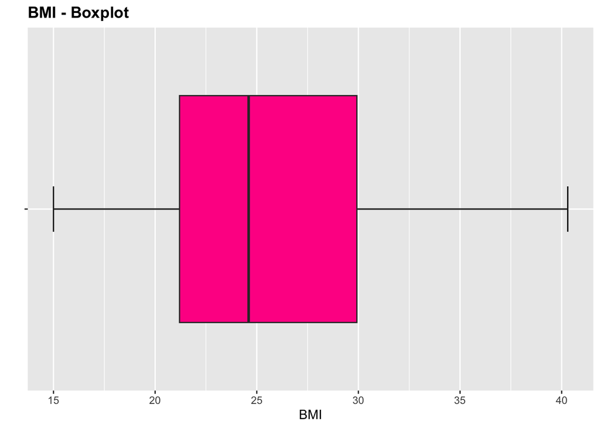

```r
df %>%
  ggplot(aes(x="", y=BMI)) +
  stat_boxplot(geom = "errorbar", width = 0.15) +
  geom_boxplot(outlier.shape = 20, outlier.size = 3, fill = "deeppink") +
  theme(legend.position="right") +
  labs(title= "BMI - Boxplot", x="", y="BMI") +
  theme(plot.title = element_text(face = "bold")) +
  coord_flip()
```

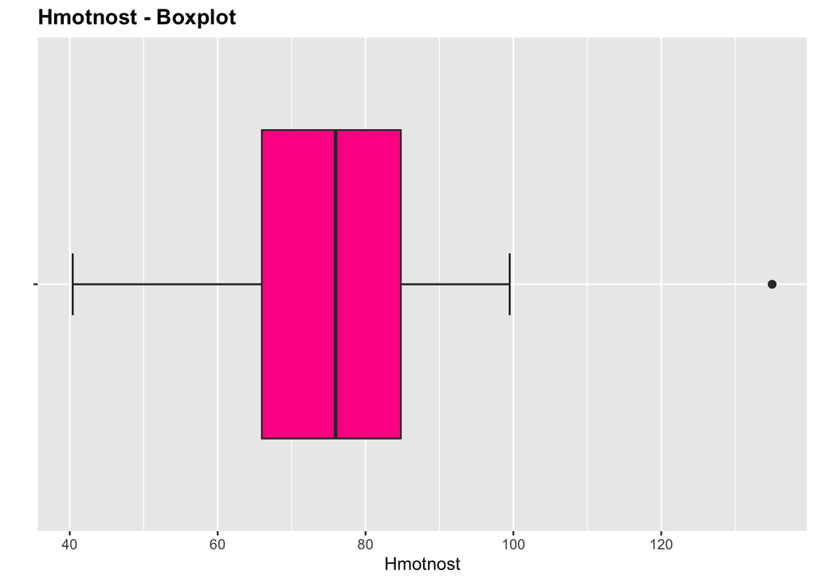

```r
df %>%
  ggplot(aes(x="", y=Hmotnost)) +
  stat_boxplot(geom = "errorbar", width = 0.15) +
  geom_boxplot(outlier.shape = 20, outlier.size = 3, fill = "deeppink") +
  theme(legend.position="right") +
  labs(title= "Hmotnost - Boxplot", x="", y="Hmotnost") +
  theme(plot.title = element_text(face = "bold")) +
  coord_flip()
```

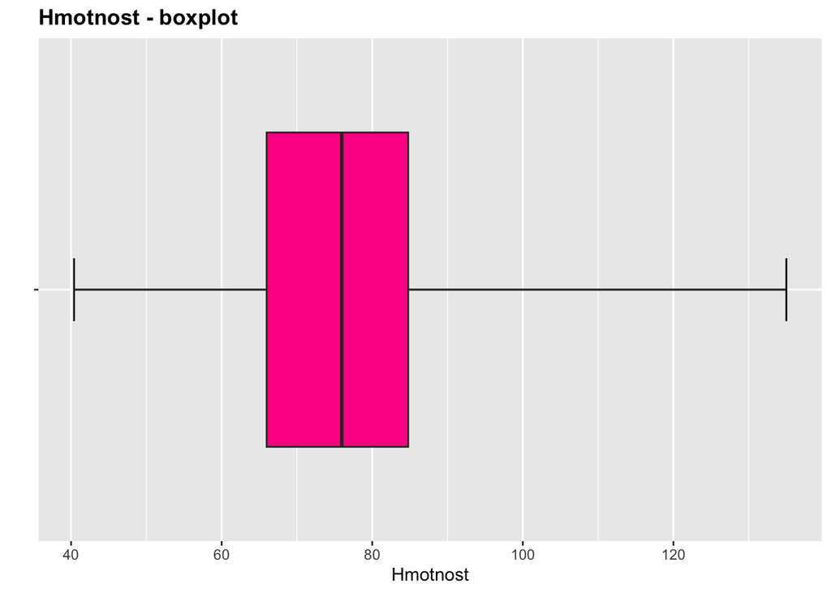

```r
df %>%
  ggplot(aes(x="", y=Hmotnost)) +
  stat_boxplot(geom = "errorbar", width = 0.15, coef=500) +
  geom_boxplot(coef=500, fill = "deeppink") +
  theme(legend.position="right") +
  labs(title= "Hmotnost - boxplot", x="", y="Hmotnost") +
  theme(plot.title = element_text(face = "bold")) +
  coord_flip()
```

```r
# parametr coef=500 rozšíří oblast, v níž se hodnoty neberou jako odlehlé (standard je coef=1.5)
```

### Jádrový odhad hustoty - graf

- je metoda pro odhad hustoty pravděpodobnosti spojité náhodné proměnné

```r
df %>%
  ggplot(aes(x=sloupec)) +
  geom_histogram(aes(y=..density..), fill="magenta", alpha=0.25, binwidth = 10) +
  geom_density(color="deeppink") +
  labs(title="Jádrový odhad hustoty", x="sloupec", y="Hustota") +
  theme(plot.title = element_text(face = "bold"))
```

**Graf s jedním jádrovým odhadem hustoty**

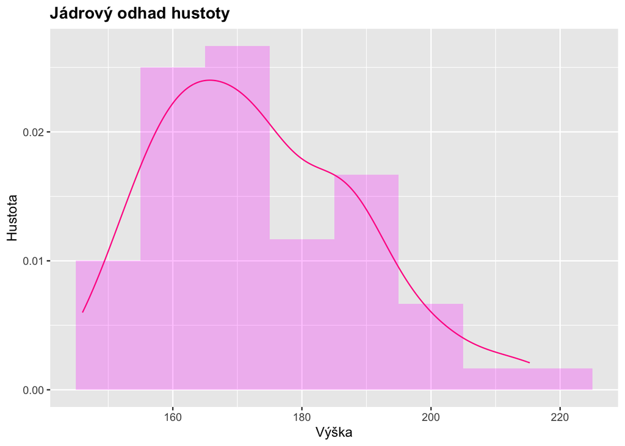

```r
df %>%
  ggplot(aes(x=Výška)) +
  geom_histogram(aes(y=..density..), fill="magenta", alpha=0.25, binwidth = 10) +
  geom_density(color="deeppink") +
  labs(title="Jádrový odhad hustoty", x="Výška", y="Hustota") +
  theme(plot.title = element_text(face = "bold"))
```

**Graf s více jádrovými odhady hustoty**

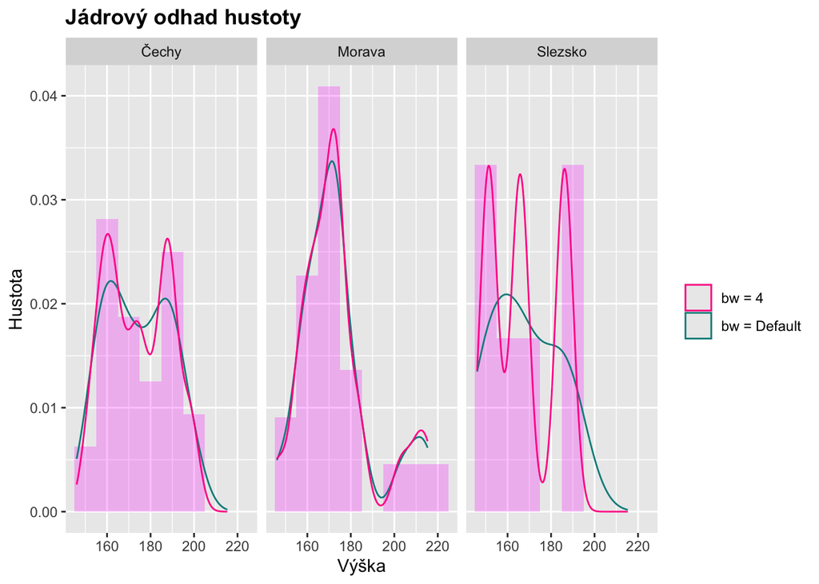

```r
df %>%
  ggplot(aes(x = Výška)) +
  geom_histogram(aes(y = ..density..), fill = "magenta", alpha = 0.25, binwidth = 10) +

  geom_density(aes(color = "bw = Default")) + # hodnota bw se určuje pomocí Silvermanova pravidla
  geom_density(aes(color = "bw = 4"), bw = 4) +

  scale_color_manual(values = c("bw = Default" = "darkcyan", "bw = 4" = "deeppink"), name = "") +
  labs(title = "Jádrový odhad hustoty", x = "Výška", y = "Hustota") +
  theme(plot.title = element_text(face = "bold")) +
  facet_wrap(~Bydliště)
```

### QQ-Plot

```r
df %>%
  ggplot(aes(sample = sloupec)) +
  geom_qq(color="deeppink") +
  stat_qq_line(color="deeppink") +
  labs(title = "QQ-plot pro sloupec", x = "Teoretické kvantily", y = "Kvantily dat") +
  theme(plot.title = element_text(face = "bold"))
```

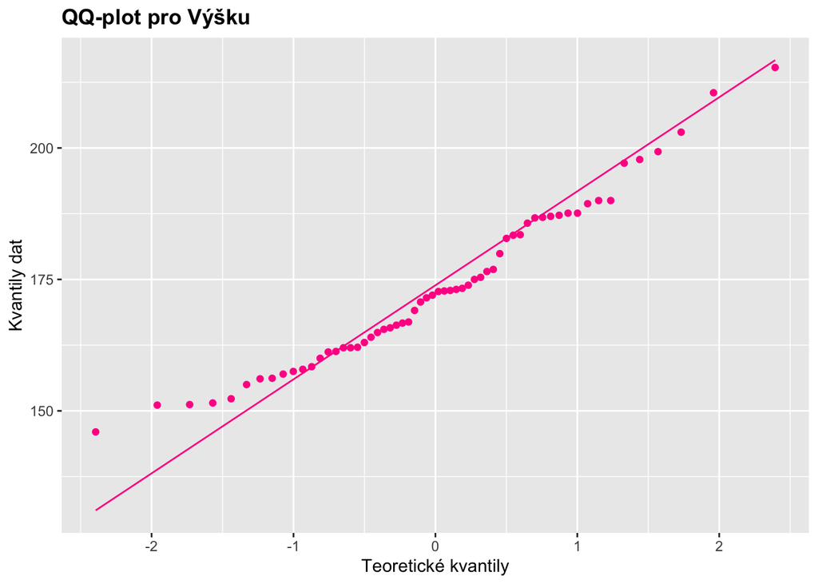

```r
df %>%
  ggplot(aes(sample = Výška)) +
  geom_qq(color="deeppink") +
  stat_qq_line(color="deeppink") +
  labs(title = "QQ-plot pro Výšku", x = "Teoretické kvantily", y = "Kvantily dat") +
  theme(plot.title = element_text(face = "bold"))
```

#### Odebrání nulových hodnot

```r
df_bez_nulovych_hodnot <- df %>% filter(sloupec != 0)
```

#### Diskrétní proměnná

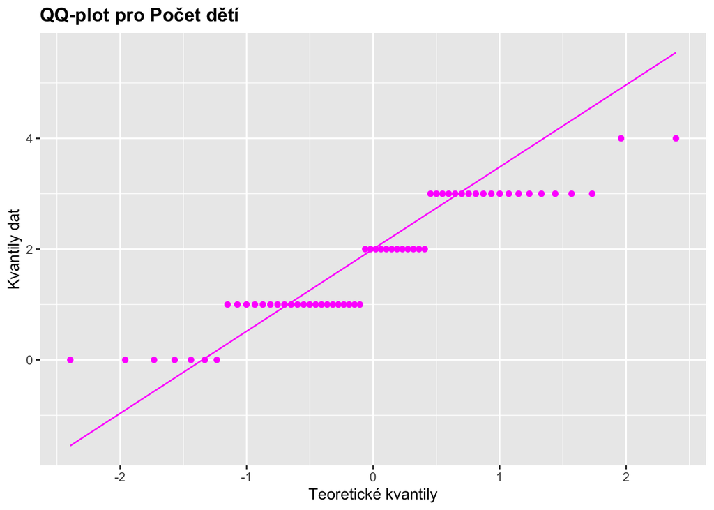

```r
df %>%
  ggplot(aes(sample = Dětí)) +
  geom_qq(color="magenta") +
  stat_qq_line(color="magenta") +
  labs(title = "QQ-plot pro Počet dětí", x = "Teoretické kvantily", y = "Kvantily dat") +
  theme(plot.title = element_text(face = "bold"))
```

# 2. Normalita dat

- jak jsou různé hodnoty rozděleny, jak často se hodnoty vyskytují v souboru dat
- **Normální rozdělení (Gaussovo)**
  - symetrické, data soustředěna kolem průměru
  - výška lidí, IQ, krevní tlak
  - grafy:
    1. Histogram: symetrický tvar ve formě zvonu, s vrcholem uprostřed, pokles četnosti na krajích
    2. Boxplot: medián uprostřed boxu, stejná délka whiskerů na obou stranách 3.QQ-Plot: bodová křivka na čáře, pokud se odchylují na koncích - extrémní hodnoty?

### Shapiro-Wilkův test normality

- **Nulová hypotéza**: Data mají normální rozdělení.
- **Alternativní hypotéza**: Data nemají normální rozdělení.
- **Hladina významnosti**: 0.05 (případně 0.1 nebo 0.01)

```r
shapiro.test(df$sloupec)
```

```r
shapiro.test(df$Výška)
```

```
    Shapiro-Wilk normality test

data:  df$Výška
W = 0.96521, p-value = 0.08481
```

- **W =** : Čím je hodnota blíže k 1, tím více jsou data podobná normálnímu rozdělení
- **p-value =** : určuje, zda můžeme zamítnout nulovou hypotézu
  1. p-value > hladina významnosti - data jsou normálně rozdělena
  2. p-value < hladina významnosti - data nejsou normálně rozdělena

# 4. Typy rozdělení pravděpodobnosti

# 5.Intervaly spolehlivosti

Odhadněte výšku studentů Přírodovědecké fakulty UJEP za předpokladu, že výška má normální rozdělení.

```r
# BODOVÝ ODHAD STŘEDNÍ HODNOTY
vysky <- c(172, 183, 197, 180, 170, 170, 177, 170, 168, 178, 184, 169)
mean(vysky)
```

```
[1] 176.5
```

#### Interval spolehlivosti využívající Studentovo rozdělení (malý vzorek, neznáme rozptyl celé populace)

```r
# Intervalový odhad (spolehlivost 0.95)
MeanCI(vysky, method="classic", conf.level = 0.95, sides="two.sided")
```

```
    mean   lwr.ci   upr.ci
176.5000 171.0512 181.9488
```

```r
# S 95% spolehlivostí je střední hodnota výšky žáků mezi __ cm a __ cm.
```

#### Interval spolehlivosti využívající BOOTSTRAP (opakované vzorkování dat)

```r
# Intervalový odhad (spolehlivost 0.95)
MeanCI(vysky, method="boot", n=1000, conf.level = 0.95, sides="two.sided")
```

```
    mean   lwr.ci   upr.ci
176.5000 171.1667 180.9167
```

```r
# S 95% spolehlivostí je střední hodnota výšky žáků mezi __ cm a __ cm.
```

```r
#Bodový odhad směrodatné odchylky
sd(vysky)
```

```
[1] 8.575865
```

```r
# Interval spolehlivosti pro rozptyl
VarCI(vysky, method="classic", conf.level = 0.95, sides="two.sided")
```

```
      var    lwr.ci    upr.ci
 73.54545  36.90685 212.01608
```

```r
# Interval spolehlivosti pro směrodatnou odchylku
sqrt(VarCI(vysky, method="classic", conf.level = 0.95, sides="two.sided"))
```

```
      var    lwr.ci    upr.ci
 8.575865  6.075101 14.560772
```

#### Interval spolehlivosti pro rozdíl (funkce MeanDiffCI)

```r
# interval spolehlivosti pro rozdíl
MeanDiffCI(neco_A,neco_B, method="classic", conf.level = 0.95, sides="two.sided")
```

#### prop.test

- pro kvalitativní data, podíl určité kategorie v populaci (podíl leváků)
- ukázka:

```r
# Předpokládejme, že mezi 200 dotazovanými (náhodně vybranými z dané populace) je 26 leváků.
# Sestrojte 95% oboustranný interval spolehlivosti pro podíl leváků v celé dané populaci.
# O jaké pravděpodobnostní rozdělení jde (u každého dotazovanéno rozlišujeme pouze to, zda je, či není levák)? binomické

#p = 26/200 = 13/100 = 0.13 ... podíl leváků v našem vzorku = bodový odhad posílu leváků v populaci

prop.test(x=26, n=200, alternative="two.sided", conf.level = 0.95)
```

```
    1-sample proportions test with continuity correction

data:  26 out of 200, null probability 0.5
X-squared = 108.05, df = 1, p-value < 2.2e-16
alternative hypothesis: true p is not equal to 0.5
95 percent confidence interval:
 0.08819814 0.18648006
sample estimates:
   p
0.13
```

#### t.test

- pro kvantitativní data
- testování hypotézy o střední hodnotě … zda je rovna, porovnání mezi dvěma nezávislými/závislými skupinami
- **příklad**: Lze výrobcem udávanou spotřebu 8.8 l/100 km považovat za pravdivou? Předpokládejte, že data mají normální rozdělení a volte α = 0.05.

```r
spotreba <- c(8.8, 8.9, 9.0, 8.7, 9.3, 9.0, 8.7, 8.8, 9.4, 8.6, 8.9)
MeanCI(spotreba, method="classic", conf.level = 0.95, sides="two.sided")
```

```
    mean   lwr.ci   upr.ci
8.918182 8.751394 9.084970
```

```r
t.test(spotreba, mu = 8.8, conf.level = 0.95, alternative = "two.sided")
```

```
    One Sample t-test

data:  spotreba
t = 1.5788, df = 10, p-value = 0.1455
alternative hypothesis: true mean is not equal to 8.8
95 percent confidence interval:
 8.751394 9.084970
sample estimates:
mean of x
 8.918182
```

**p-value < a** : zamítneme nulovou hypotézu - >Střední hodnota spotřeby není 8.8 **p-value > a**: přijmeme nulovou hypotézu.

# 6. Regresní analýza

= **Analýza vztahů**, zkoumá, jak jedna proměnná ovlivňuje druhou - regresní, korelační metody

```r
deti <- read_excel("DataDetiMin.xlsx")
```

## Bodový graf dvou proměnných

```r
df %>%
  ggplot(aes(x=, y=)) +
  geom_point(color="deeppink") +
  labs(title = "Bodový graf -  a ", x = "", y = "") +
  theme(plot.title = element_text(face = "bold"))
```

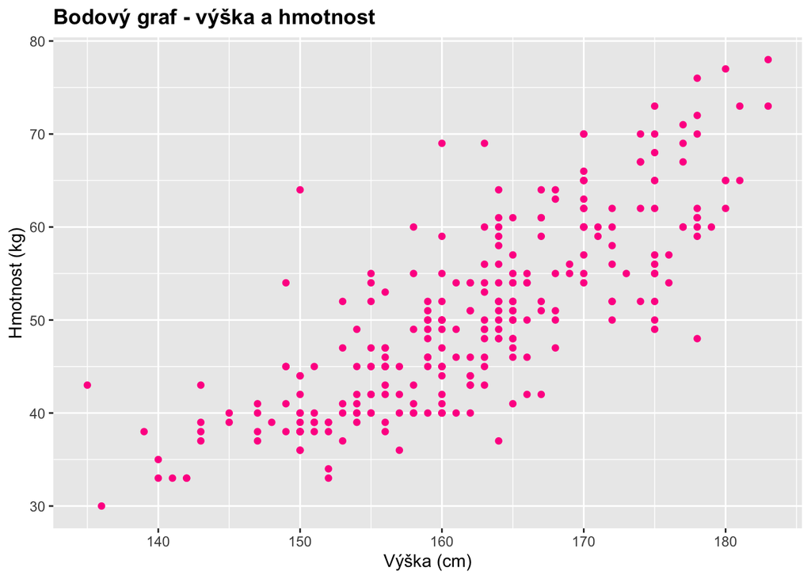

```r
deti %>%
  ggplot(aes(x=VYSKA, y=HMOTN)) +
  geom_point(color="deeppink") +
  labs(title = "Bodový graf - výška a hmotnost", x = "Výška (cm)", y = "Hmotnost (kg)") +
  theme(plot.title = element_text(face = "bold"))
```

## Typ

1. **Lineární** : body vykazují rovnou čáru
2. **Nelineární** : zakřivený tvar (parabola, …)

## Korelace

1. **Pozitivní** : rostoucí trend
2. **Negativní** : klesající trend
3. **Žádná**: žádný zjevný trend

### Pearsonův korelační koreficient

- vyjadřuje sílu a směr lineárního stavu
- r náleží **<-1 ; 1>** :
  - **r = 1** : perfektní pozitivní lineární korelace
  - **r = -1** : perfektní negativní lineární korelace
  - **r = 0** : žádná lineární korelace
  - **0 < r < 1** : pozitivní lineární korelace; roste jedna -> roste druhá
  - **-1 < r < 0**: negativní lineární korelace; roste jedna -> klesá druhá

```r
cor(x=df$sloupec1,y=df$sloupec2, method="pearson", use="pairwise.complete.obs")
```

```r
# POZITIVNÍ LINEÁRNÍ KORELACE
cor(x=deti$VYSKA,y=deti$HMOTN, method="pearson", use="pairwise.complete.obs")
```

```
[1] 0.7956237
```

### Korelační matice

```r
vyber <- df[c("","","","")]
ggpairs(vyber, title="Korelogram pro data o ...")
```

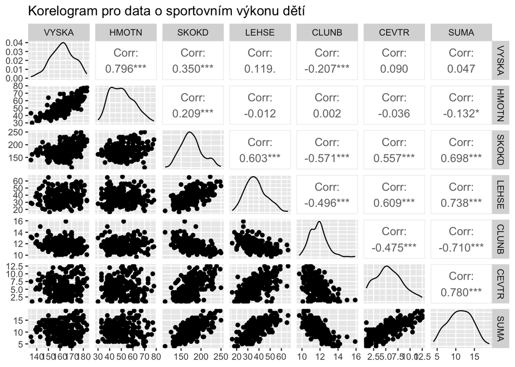

```r
vyber <- deti[c("VYSKA", "HMOTN", "SKOKD", "LEHSE", "CLUNB", "CEVTR", "SUMA")]
ggpairs(vyber, title="Korelogram pro data o sportovním výkonu dětí")
```

## Kontigenční tabulka

```r
kontingencni_tabulka <- table(df$sloupec1, df$sloupec2)
addmargins(kontingencni_tabulka, margin = c(1,2))
```

```r
# SOUVISLOST HORMONÁLNÍ ANTIKONCEPCE A VÝSKYTU TROMBÓZY
kontingencni_tabulka <- table(df$`Hormonální antikoncepce`, df$Trombóza)
addmargins(kontingencni_tabulka, margin = c(1,2))
```

```
         False True Sum
  bere       6   40  46
  nebere     2   12  14
  Sum        8   52  60
```

###Kontingenční tabulka s procentuálními podíly (součty v řádku)

```r
# procenta řádkových součtů
kontingencni_procenta_radky <- round(prop.table(kontingencni_tabulka, margin = 1),3) * 100
kontingencni_procenta_radky
```

```
         False True
  bere    13.0 87.0
  nebere  14.3 85.7
```

###Kontingenční tabulka s procentuálními podíly (součty ve sloupci)

```r
# procenta sloupcových součtů
kontingencni_procenta_sloupce <- round(prop.table(kontingencni_tabulka, margin = 2),3) * 100
kontingencni_procenta_sloupce
```

```
         False True
  bere    75.0 76.9
  nebere  25.0 23.1
```

### Grafické znázornění podílů kontigenční tabulky

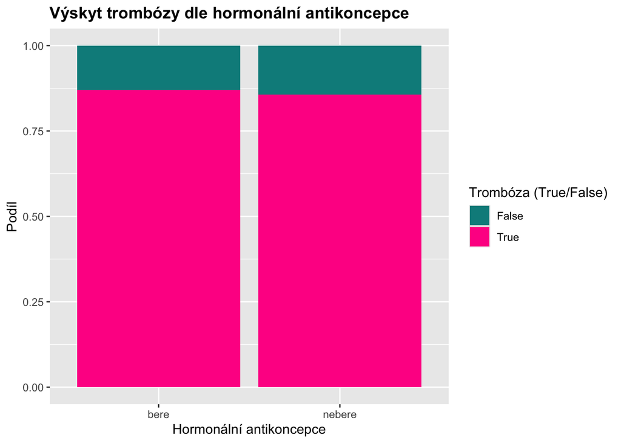

```r
df %>%
  ggplot(aes(x = `Hormonální antikoncepce`, fill = Trombóza)) +
  geom_bar(position = "fill")+
  labs(title = "Výskyt trombózy dle hormonální antikoncepce",
       x = "Hormonální antikoncepce",
       y = "Podíl",
       fill = "Trombóza (True/False)") +
  theme(plot.title = element_text(face = "bold")) +
  scale_fill_manual(values = c("True" = "deeppink", "False" = "darkcyan"))
```

## Chí kvadrát test

- závislost dvou kategoriálních veličin
- **Nulová hypotéza**: Veličiny jsou nezávislé.
- **Alternativní hypotéza**: Veličiny nejsou nezávislé.
- **Hladina významnosti**: 0.05 (případně 0.1 nebo 0.01)

```r
chisq.test(kontingencni_tabulka)
```

```
    Pearson's Chi-squared test with Yates' continuity correction

data:  kontingencni_tabulka
X-squared = 2.3427e-31, df = 1, p-value = 1
```

- **p-value =** : určuje, zda můžeme zamítnout nulovou hypotézu
  1. p-value > hladina významnosti - nulová hypotéza platí
  2. p-value < hladina významnosti - zamítáme nulovou hypotézu

### Regresní přímka

Popíšeme závislost proměnných pomocí **lineární funkce** (metodou nejmenších čtverců):

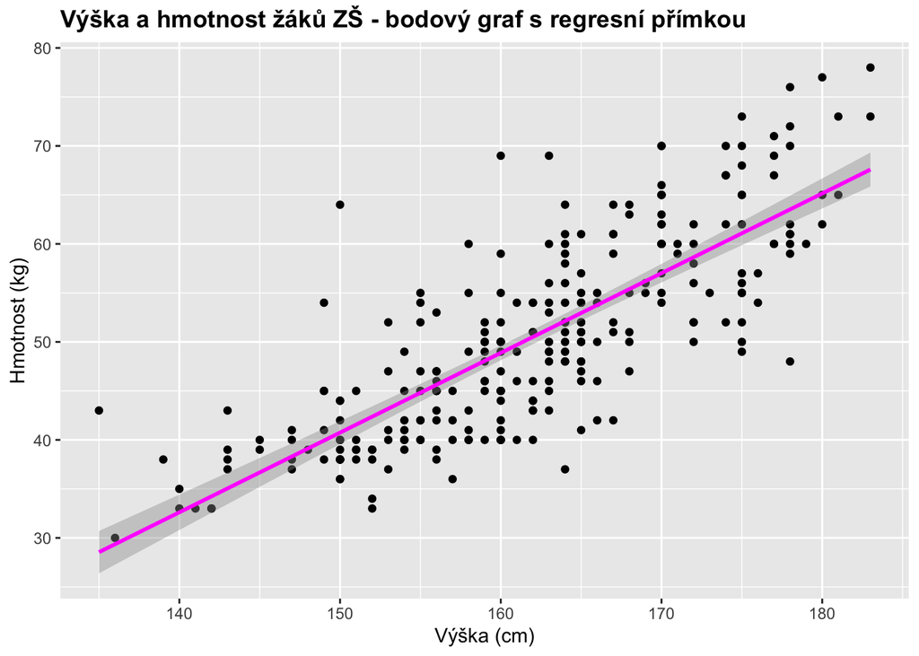

```r
deti %>%
  ggplot(aes(x = VYSKA, y = HMOTN)) +
  geom_point() +
  labs(title = "Výška a hmotnost žáků ZŠ - bodový graf s regresní přímkou", x = "Výška (cm)", y = "Hmotnost (kg)") +
  theme(plot.title = element_text(face = "bold")) +
  geom_smooth(method = "lm", se = TRUE, color = "magenta") # Přidání regresní přímky (parametr lm značí lineární regresi, parametrem se=FALSE nezobrazíme intervaly spolehlivosti)
```

#### Rovnice regresní přímky

Zjistíme rovnici této lineární funce, tj. regresní přímky:

```r
# parametry lm se zadávají v pořadí "závisle proměnná" (u nás na ose y)" ~ "nezávisle proměnná" (u nás na ose x)
regrese <- lm(HMOTN ~ VYSKA , data = deti)
regrese
```

```
Call:
lm(formula = HMOTN ~ VYSKA, data = deti)

Coefficients:
(Intercept)        VYSKA
   -81.2790       0.8135
```

**(Intercept)** : průsečík s osou y  
**SLOUPEC** : směrnice přímky  
**sloupec na ose y = SLOUPEC * sloupec na ose x + (Intercept)**

```r
intercept <- coef(regrese)[1]     # Průsečík s osou y
smernice <- coef(regrese)[2]      # Směrnice
cat("Rovnice regresní přímky: HMOTN =", intercept, "+", smernice, "* VYSKA")
```

```
Rovnice regresní přímky: HMOTN = -81.27901 + 0.8134979 * VYSKA
```

**Vyhodnocení regresního modelu:**

```r
summary(regrese)
```

```
Call:
lm(formula = HMOTN ~ VYSKA, data = deti)

Residuals:
     Min       1Q   Median       3Q      Max
-15.5236  -3.9997  -0.6267   3.4923  23.2543

Coefficients:
             Estimate Std. Error t value Pr(>|t|)
(Intercept) -81.27901    6.17813  -13.16   <2e-16 ***
VYSKA         0.81350    0.03805   21.38   <2e-16 ***
---
Signif. codes:  0 '***' 0.001 '**' 0.01 '*' 0.05 '.' 0.1 ' ' 1

Residual standard error: 6.132 on 265 degrees of freedom
Multiple R-squared:  0.633, Adjusted R-squared:  0.6316
F-statistic: 457.1 on 1 and 265 DF,  p-value: < 2.2e-16
```

**RESIDUALS** - reziduály; rozdíly skutečných a očekávaných hodnot

### PŘÍKLAD

Vytvořte regresní model, který popíše závislost proměnné *Proměnná* na zbývajících proměnných, a interpretujte ho.

```r
# Překódování proměnné Proměnná (1 = Yes, 0 = No)
df$Proměnná <- ifelse(df$Proměnná == "Yes", 1, 0)
```

```r
# Vytvoření regresního modelu a vypsání jeho parametrů
regresni_model <- lm(Proměnná ~ Zbývající_proměnná + Zbývající_proměnná + Zbývající_proměnná, data=df)
regresni_model
```